# CNN - Modelling (Binary + MOG + Standalone TL)

# 1. Construct MLP

```python
import tensorflow as tf
%matplotlib inline

print(tf.__version__)
```

```
2.4.2
```

```python
! nvidia-smi
```

```
/bin/bash: switchml: line 1: syntax error: unexpected end of file
/bin/bash: error importing function definition for `switchml'
/bin/bash: _moduleraw: line 1: syntax error: unexpected end of file
/bin/bash: error importing function definition for `_moduleraw'
Wed Aug 11 13:33:17 2021
+-----------------------------------------------------------------------------+
| NVIDIA-SMI 450.142.00   Driver Version: 450.142.00   CUDA Version: 11.0     |
|-------------------------------+----------------------+----------------------+
| GPU  Name        Persistence-M| Bus-Id        Disp.A | Volatile Uncorr. ECC |
| Fan  Temp  Perf  Pwr:Usage/Cap|         Memory-Usage | GPU-Util  Compute M. |
|                               |                      |               MIG M. |
|===============================+======================+======================|
|   0  Tesla T4            On   | 00000000:00:1E.0 Off |                    0 |
| N/A   42C    P8    10W /  70W |      0MiB / 15109MiB |      0%      Default |
|                               |                      |                  N/A |
+-------------------------------+----------------------+----------------------+

+-----------------------------------------------------------------------------+
| Processes:                                                                  |
|  GPU   GI   CI        PID   Type   Process name                  GPU Memory |
|        ID   ID                                                   Usage      |
|=============================================================================|
|  No running processes found                                                 |
+-----------------------------------------------------------------------------+
```

Use MLP on the extracted features to make prediction.

```python
from crack_utils import classification_block
from tensorflow.keras.models import Model
from tensorflow.keras.layers import Input

# define MLP model
def MLP(input_size):
    # define model input
    visible = Input(shape=(input_size, ))
    # add classification block
    layer = classification_block(visible, 16)
    # create model
    model = Model(inputs=visible, outputs=layer)
    return model
```

# 2. Pretrain Model as Standalone Feature Extractor

Use all layes previous to the output layer.

## 2.1 VGG19

```python
from tensorflow.keras.applications import VGG19

# create model instance
model = VGG19()
# remove the output layer
model = Model(inputs=model.inputs, outputs=model.layers[-2].output)
```

[output not shown]

Preprocess images and extract features: Due to the insufficient memory issue, we extract the features in 10 batches:

```python
from crack_utils import load_binary_dataset, extract_in_batch
from tensorflow.keras.applications.vgg19 import preprocess_input as pre_vgg19

SRC_BINARY = "/home/ubuntu/crack/MOG-Binary"

x_train, x_test, y_train, y_test = load_binary_dataset(SRC_BINARY, (224, 224))
x_train = extract_in_batch(10, x_train, model, "train", pre_vgg19)
x_test = extract_in_batch(10, x_test, model, "test", pre_vgg19)
feature_length = x_train.shape[1]
```

```
Processing 10 batch of test-set....
```

Fit MLP model:

```python
%%time

from crack_utils import binary_compile

# create model instance
model = MLP(feature_length)
binary_compile(model, 0.01, 0.9)

# fit the model
histories = dict()

histories["Bi_MOG_TL1_VGG19"] = model.fit(x=x_train, y=y_train, batch_size=64,
              validation_data=(x_test, y_test), epochs=30, verbose=0).history
```

```
CPU times: user 22.3 s, sys: 3.34 s, total: 25.7 s
Wall time: 11.5 s
```

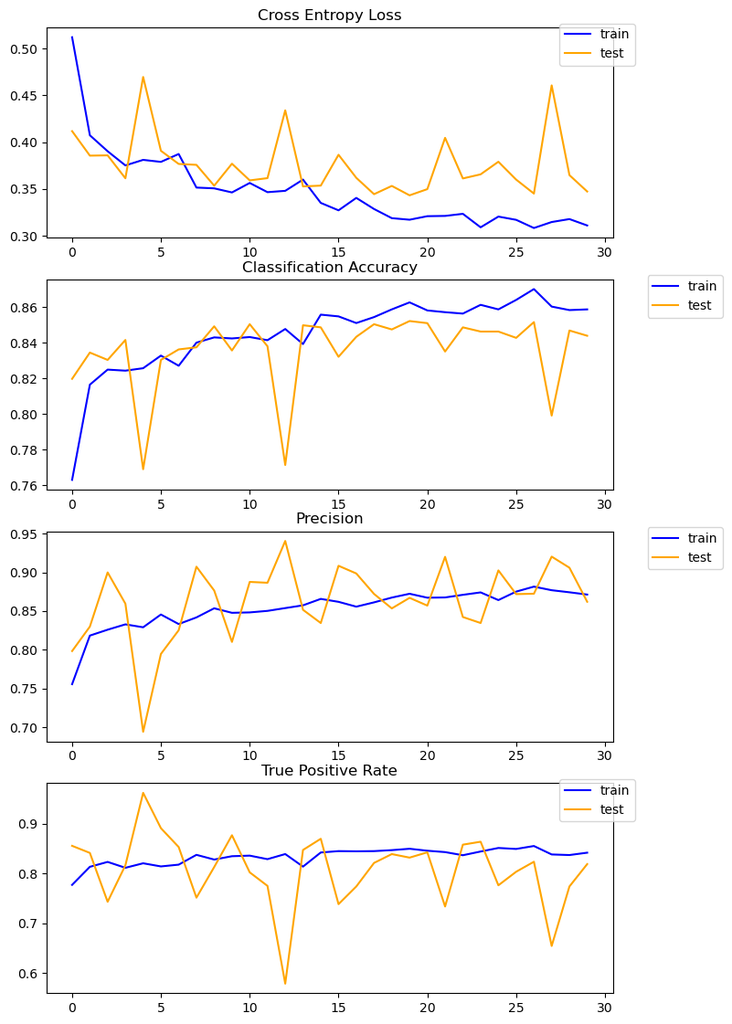

```python
from crack_utils import summarize_diagnostics_binary

summarize_diagnostics_binary(histories["Bi_MOG_TL1_VGG19"], "model_plot/Bi_MOG_TL1_VGG19.png")
```

```python
from crack_utils import show_result

show_result(model, x_test, y=y_test)
```

```
Test loss: 0.35
Test Accuracy: 0.84
Test Precision: 0.86
Test True Positive Rate: 0.82
```

## 2.2 ResNet152V2

```python
from tensorflow.keras.applications import ResNet152V2

# create model instance
model = ResNet152V2()
# remove the output layer
model = Model(inputs=model.inputs, outputs=model.layers[-2].output)
```

Preprocess images and extract features: Due to the insufficient memory issue, we extract the features in 10 batches:

```python
from tensorflow.keras.applications.resnet_v2 import preprocess_input as pre_resnet_v2

del x_train, x_test
x_train, x_test, y_train, y_test = load_binary_dataset(SRC_BINARY, (224, 224))
x_train = extract_in_batch(10, x_train, model, "train", pre_resnet_v2)
x_test = extract_in_batch(10, x_test, model, "test", pre_resnet_v2)
feature_length = x_train.shape[1]
```

```
Processing 10 batch of test-set....
```

Fit MLP model:

```python
%%time

# create model instance
model = MLP(feature_length)
binary_compile(model, 0.01, 0.9)

histories["Bi_MOG_TL1_ResNet152V2"] = model.fit(x=x_train, y=y_train, batch_size=64,
              validation_data=(x_test, y_test), epochs=30, verbose=0).history
```

```
CPU times: user 21 s, sys: 2.79 s, total: 23.8 s
Wall time: 10.1 s
```

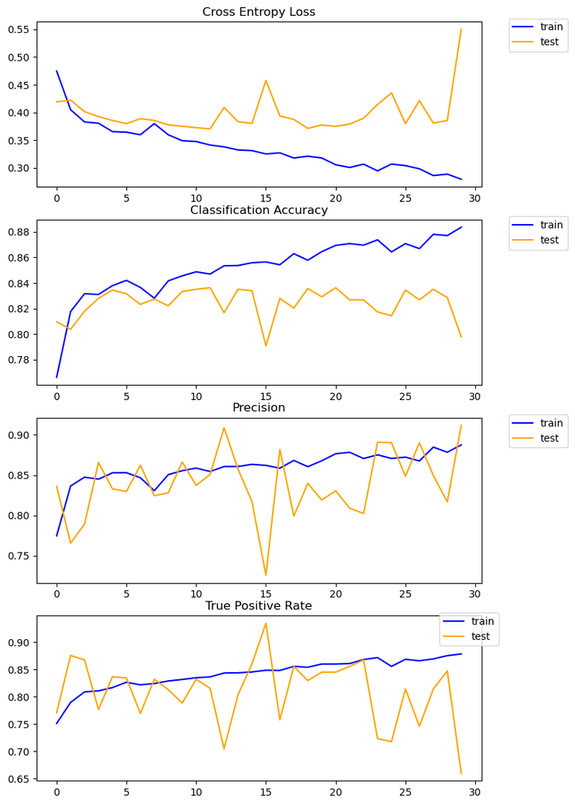

```python
summarize_diagnostics_binary(histories["Bi_MOG_TL1_ResNet152V2"],
                             "model_plot/Bi_MOG_TL1_ResNet152V2.png")
```

```python
show_result(model, x_test, y=y_test)
```

```
Test loss: 0.55
Test Accuracy: 0.80
Test Precision: 0.91
Test True Positive Rate: 0.66
```

## 2.3 NASNetLarge

```python
from tensorflow.keras.applications import NASNetLarge

# create model instance
model = NASNetLarge()
# remove the output layer
model = Model(inputs=model.inputs, outputs=model.layers[-2].output)
```

Preprocess images and extract features: Due to the insufficient memory issue, we extract the features in 30 batches:

```python
from tensorflow.keras.applications.nasnet import preprocess_input as pre_nasnet

del x_train, x_test
x_train, x_test, y_train, y_test = load_binary_dataset(SRC_BINARY, (331, 331))
x_train = extract_in_batch(30, x_train, model, "train", pre_nasnet)
x_test = extract_in_batch(30, x_test, model, "test", pre_nasnet)
feature_length = x_train.shape[1]
```

```
Processing 30 batch of test-set....
```

Fit MLP model:

```python
%%time

# create model instance
model = MLP(feature_length)
binary_compile(model, 0.01, 0.9)

histories["Bi_MOG_TL1_NASNetLarge"] = model.fit(x=x_train, y=y_train, batch_size=64,
              validation_data=(x_test, y_test), epochs=30, verbose=0).history
```

```
CPU times: user 21.6 s, sys: 3.2 s, total: 24.8 s
Wall time: 10.9 s
```

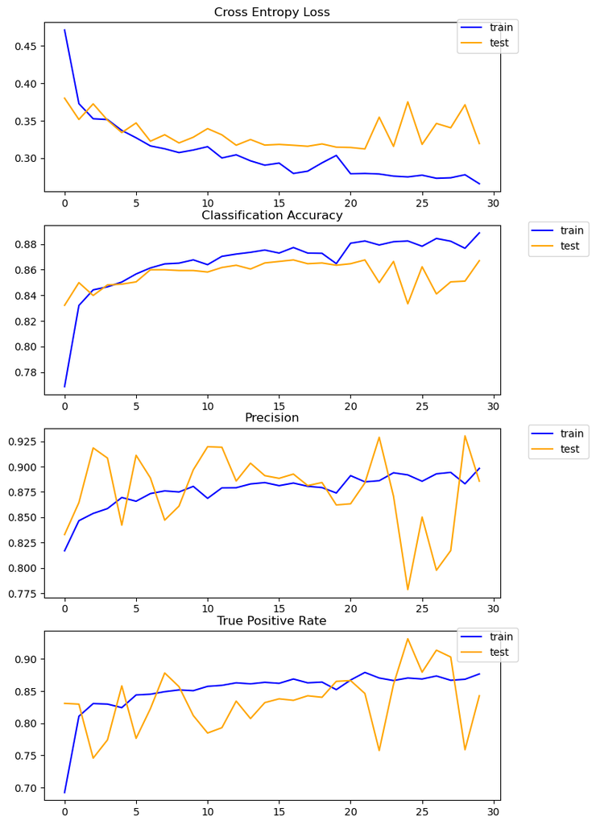

```python
summarize_diagnostics_binary(histories["Bi_MOG_TL1_NASNetLarge"], "model_plot/Bi_MOG_TL1_NASNetLarge.png")
```

```python
show_result(model, x_test, y=y_test)
```

```
Test loss: 0.32
Test Accuracy: 0.87
Test Precision: 0.89
Test True Positive Rate: 0.84
```

## 2.4 DenseNet201

```python
from tensorflow.keras.applications import DenseNet201

# create model instance
model = DenseNet201()
# remove the output layer
model = Model(inputs=model.inputs, outputs=model.layers[-2].output)
```

Preprocess images and extract features: Due to the insufficient memory issue, we extract the features in 10 batches:

```python
from tensorflow.keras.applications.densenet import preprocess_input as pre_densenet

del x_train, x_test
x_train, x_test, y_train, y_test = load_binary_dataset(SRC_BINARY, (224, 224))
x_train = extract_in_batch(10, x_train, model, "train", pre_densenet)
x_test = extract_in_batch(10, x_test, model, "test", pre_densenet)
feature_length = x_train.shape[1]
```

```
Processing 10 batch of test-set....
```

Fit MLP model:

```python
%%time

# create model instance
model = MLP(feature_length)
binary_compile(model, 0.01, 0.9)

histories["Bi_MOG_TL1_DenseNet201"] = model.fit(x=x_train, y=y_train, batch_size=64,
              validation_data=(x_test, y_test), epochs=30, verbose=0).history
```

```
CPU times: user 20 s, sys: 3.04 s, total: 23 s
Wall time: 9.75 s
```

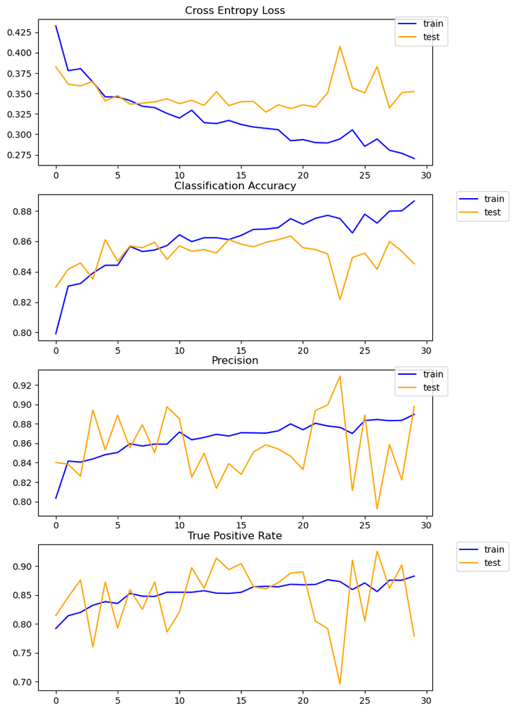

```python
summarize_diagnostics_binary(histories["Bi_MOG_TL1_DenseNet201"],
                             "model_plot/Bi_MOG_TL1_DenseNet201.png")
```

```python
show_result(model, x_test, y=y_test)
```

```
Test loss: 0.35
Test Accuracy: 0.85
Test Precision: 0.90
Test True Positive Rate: 0.78
```

## 2.5 InceptionV3

```python
from tensorflow.keras.applications import InceptionV3

# create model instance
model = InceptionV3()
# remove the output layer
model = Model(inputs=model.inputs, outputs=model.layers[-2].output)
```

Preprocess images and extract features: Due to the insufficient memory issue, we extract the features in 10 batches:

```python
from tensorflow.keras.applications.inception_v3 import preprocess_input as pre_inception_v3

del x_train, x_test
x_train, x_test, y_train, y_test = load_binary_dataset(SRC_BINARY, (299,299))
x_train = extract_in_batch(10, x_train, model, "train", pre_inception_v3)
x_test = extract_in_batch(10, x_test, model, "test", pre_inception_v3)
feature_length = x_train.shape[1]
```

```
Processing 10 batch of test-set....
```

Fit MLP model:

```python
%%time

# create model instance
model = MLP(feature_length)
binary_compile(model, 0.01, 0.9)

histories["Bi_MOG_TL1_InceptionV3"] = model.fit(x=x_train, y=y_train, batch_size=64,
              validation_data=(x_test, y_test), epochs=30, verbose=0).history
```

```
CPU times: user 21 s, sys: 3.19 s, total: 24.1 s
Wall time: 10.3 s
```

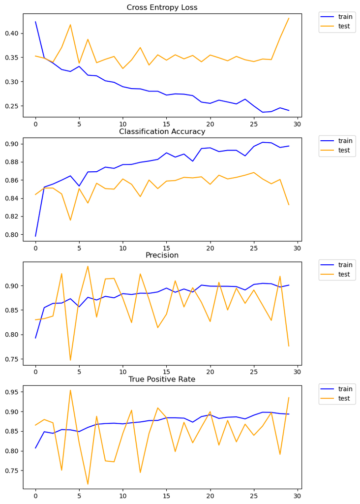

```python
summarize_diagnostics_binary(histories["Bi_MOG_TL1_InceptionV3"], "model_plot/Bi_MOG_TL1_InceptionV3.png")
```

```python
show_result(model, x_test, y=y_test)
```

```
Test loss: 0.43
Test Accuracy: 0.83
Test Precision: 0.78
Test True Positive Rate: 0.93
```

## 2.6 InceptionResNetV2

```python
from tensorflow.keras.applications import InceptionResNetV2

# create model instance
model = InceptionResNetV2()
# remove the output layer
model = Model(inputs=model.inputs, outputs=model.layers[-2].output)
```

Preprocess images and extract features: Due to the insufficient memory issue, we extract the features in 10 batches:

```python
from tensorflow.keras.applications.inception_resnet_v2 import preprocess_input as pre_inception_resnet_v2

del x_train, x_test
x_train, x_test, y_train, y_test = load_binary_dataset(SRC_BINARY, (299,299))
x_train = extract_in_batch(10, x_train, model, "train", pre_inception_resnet_v2)
x_test = extract_in_batch(10, x_test, model, "test", pre_inception_resnet_v2)
feature_length = x_train.shape[1]
```

```
Processing 10 batch of test-set....
```

Fit MLP model:

```python
%%time

# create model instance
model = MLP(feature_length)
binary_compile(model, 0.01, 0.9)

histories["Bi_MOG_TL1_InceptionResNetV2"] = model.fit(x=x_train, y=y_train, batch_size=64,
              validation_data=(x_test, y_test), epochs=30, verbose=0).history
```

```
CPU times: user 20.3 s, sys: 3.03 s, total: 23.3 s
Wall time: 10 s
```

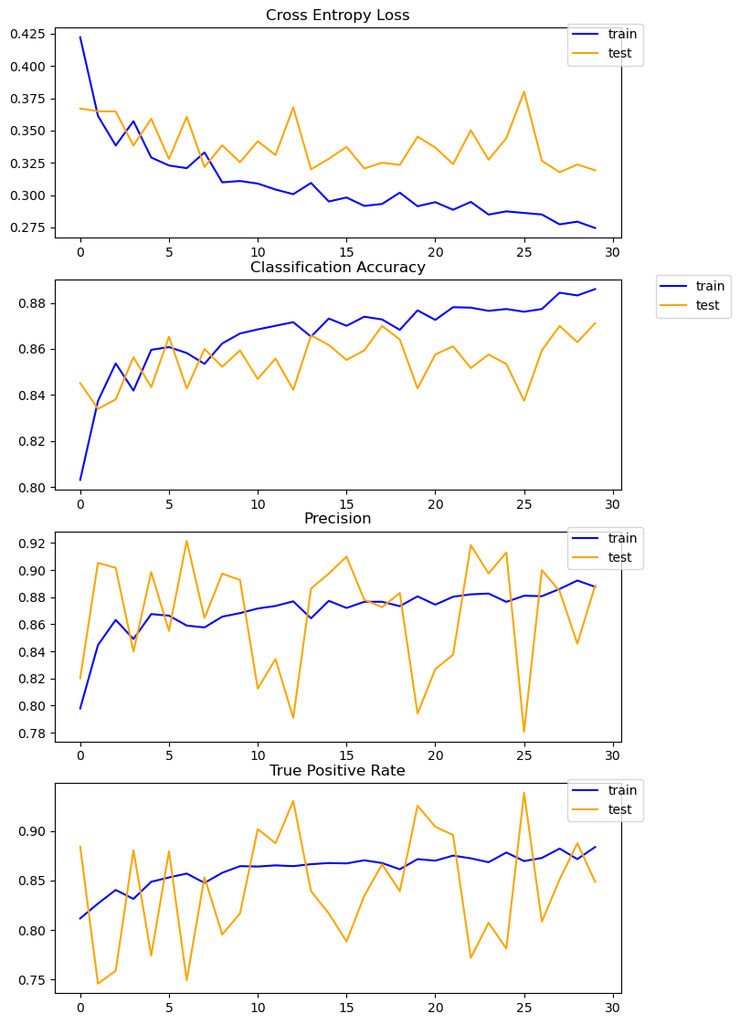

```python
summarize_diagnostics_binary(histories["Bi_MOG_TL1_InceptionResNetV2"],
                             "model_plot/Bi_MOG_TL1_InceptionResNetV2.png")
```

```python
show_result(model, x_test, y=y_test)
```

```
Test loss: 0.32
Test Accuracy: 0.87
Test Precision: 0.89
Test True Positive Rate: 0.85
```

## 2.7 Xception

```python
from tensorflow.keras.applications import Xception

# create model instance
model = Xception()
# remove the output layer
model = Model(inputs=model.inputs, outputs=model.layers[-2].output)
```

Preprocess images and extract features: Due to the insufficient memory issue, we extract the features in 10 batches:

```python
from tensorflow.keras.applications.xception import preprocess_input as pre_xception

del x_train, x_test
x_train, x_test, y_train, y_test = load_binary_dataset(SRC_BINARY, (299,299))
x_train = extract_in_batch(10, x_train, model, "train", pre_xception)
x_test = extract_in_batch(10, x_test, model, "test", pre_xception)
feature_length = x_train.shape[1]
```

```
Processing 10 batch of test-set....
```

Fit MLP model:

```python
%%time

# create model instance
model = MLP(feature_length)
binary_compile(model, 0.01, 0.9)

histories["Bi_MOG_TL1_Xception"] = model.fit(x=x_train, y=y_train, batch_size=64,
              validation_data=(x_test, y_test), epochs=30, verbose=0).history
```

```
CPU times: user 21.3 s, sys: 2.99 s, total: 24.3 s
Wall time: 10.3 s
```

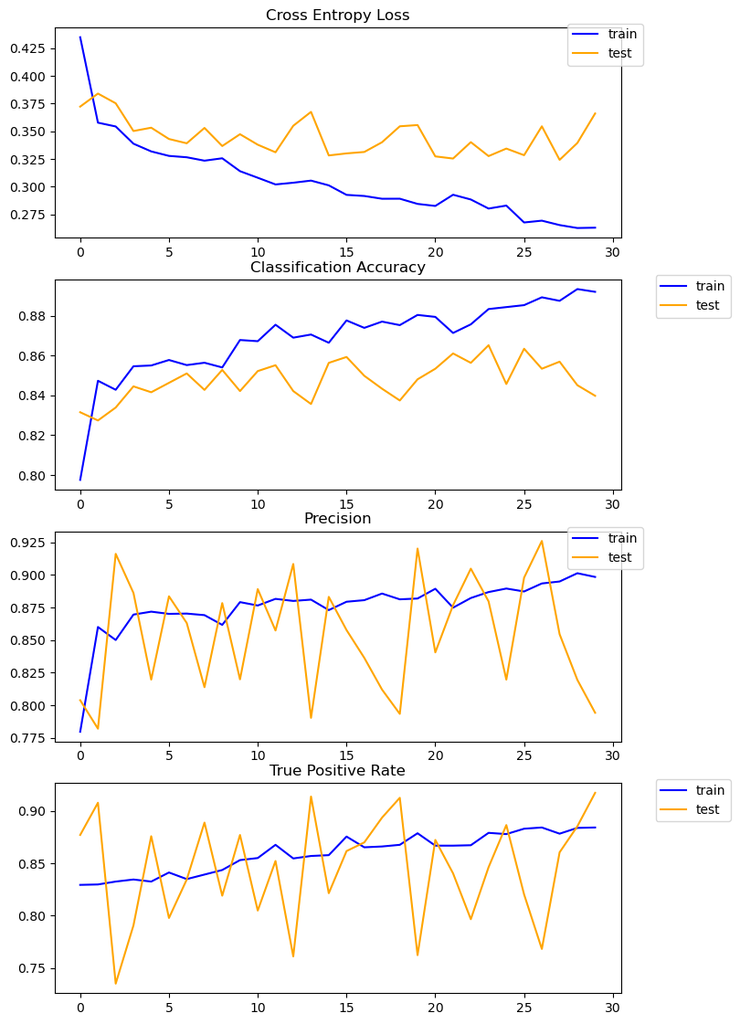

```python
summarize_diagnostics_binary(histories["Bi_MOG_TL1_Xception"], "model_plot/Bi_MOG_TL1_Xception.png")
```

```python
show_result(model, x_test, y=y_test)
```

```
Test loss: 0.37
Test Accuracy: 0.84
Test Precision: 0.79
Test True Positive Rate: 0.92
```

# 3. Summary

```python
from crack_utils import get_percentile_result

result_30 = get_percentile_result(histories, 25)
result_30.round(2)
```

|  | Bi_MOG_TL1_VGG19 | Bi_MOG_TL1_ResNet152V2 | Bi_MOG_TL1_NASNetLarge | Bi_MOG_TL1_DenseNet201 | Bi_MOG_TL1_InceptionV3 | Bi_MOG_TL1_InceptionResNetV2 | Bi_MOG_TL1_Xception |
| --- | --- | --- | --- | --- | --- | --- | --- |
| Loss | 0.38 | 0.44 | 0.38 | 0.36 | 0.34 | 0.34 | 0.33 |
| Accuracy | 0.85 | 0.81 | 0.83 | 0.85 | 0.87 | 0.85 | 0.85 |
| Precision | 0.90 | 0.89 | 0.78 | 0.81 | 0.86 | 0.91 | 0.82 |
| TPR | 0.78 | 0.72 | 0.93 | 0.91 | 0.87 | 0.78 | 0.89 |

21-30 epochs (Average):

```python
from crack_utils import get_avg_result

avg_result = get_avg_result(histories, start_epoch=21)
avg_result.round(2)
```

|  | Bi_MOG_TL1_VGG19 | Bi_MOG_TL1_ResNet152V2 | Bi_MOG_TL1_NASNetLarge | Bi_MOG_TL1_DenseNet201 | Bi_MOG_TL1_InceptionV3 | Bi_MOG_TL1_InceptionResNetV2 | Bi_MOG_TL1_Xception |
| --- | --- | --- | --- | --- | --- | --- | --- |
| Loss | 0.38 | 0.42 | 0.34 | 0.36 | 0.36 | 0.33 | 0.34 |
| Accuracy | 0.84 | 0.82 | 0.85 | 0.85 | 0.86 | 0.86 | 0.85 |
| Precision | 0.88 | 0.86 | 0.86 | 0.87 | 0.87 | 0.87 | 0.86 |
| TPR | 0.79 | 0.78 | 0.85 | 0.83 | 0.86 | 0.84 | 0.85 |

Compare each model:

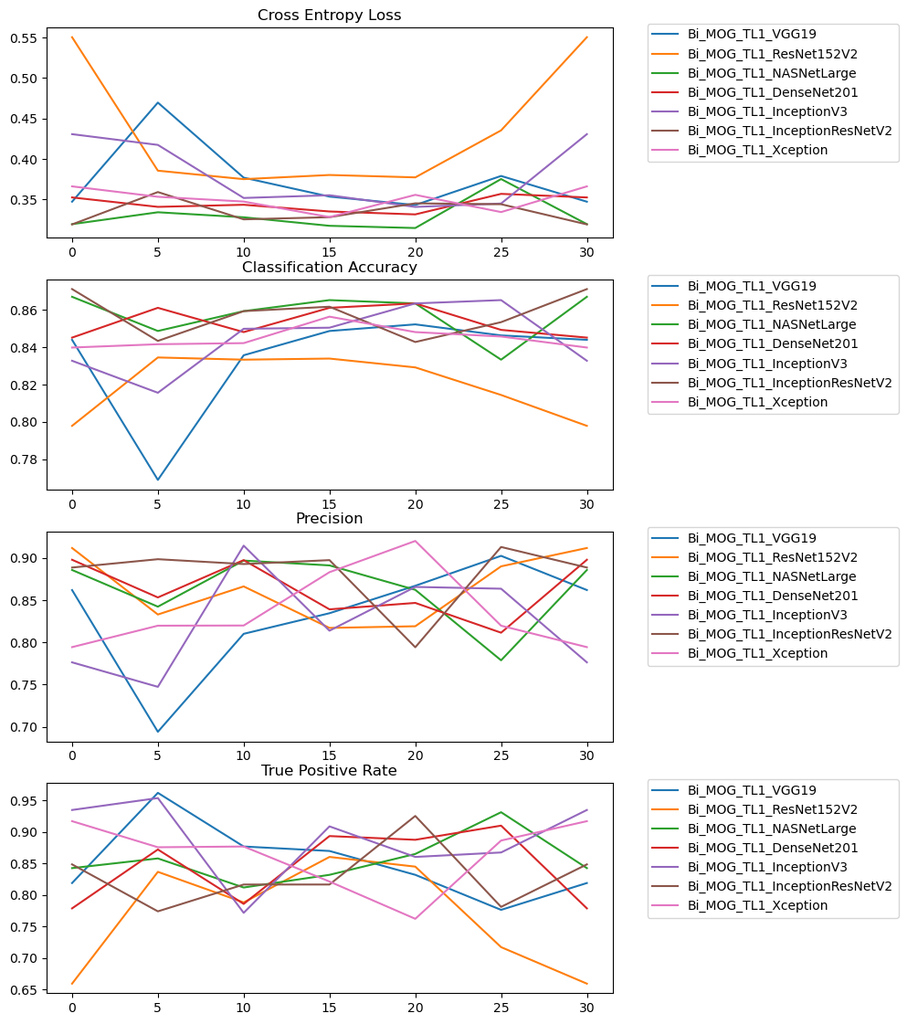

```python
from crack_utils import compare_all_result

compare_all_result(histories, filename="model_plot/Compare_Bi_MOG_Standalone_TF.png", end=30, step=5)
```

Save epochs history:

```python
from crack_utils import save_history

save_history(histories, folder="epochs_history")
```